# Borders_SDM_Tutorial

Isaac Eckert

11/11/2022

### Install and load R packages.

```r
# install.packages(c("raster", "sf", "sp", "rgdal", "ggplot2", "ggspatial", "rnaturalearth", "wesanderson"))

#data resolution = 1km

library(raster) ## for using raster data
library(dismo) # for SDM models
library(gbm) # generalized boosted regression models
library(mgcv) # mixed GAM computation vehicle
library(terra) # spatial analysis with vector or raster data
library(beepr) # play notification sound
library(RColorBrewer) # color palette
library(readr) # reading in files
```

### Read and clean data

Read in raster outline of study area using the `raster` function. Check the coordinate reference system using the `crs` function.

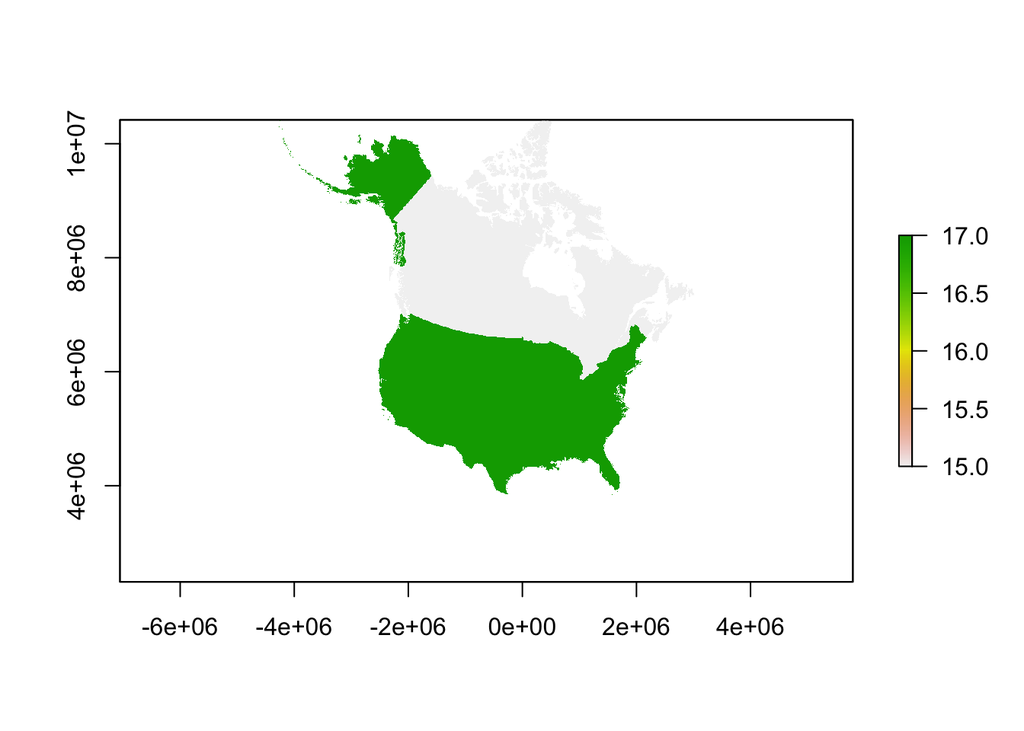

```r
getwd()
canusa <- raster("data/USCanadaOutline.tif")
plot(canusa)
```

```r
crs(canusa)
```

Create a stacked raster of climate predictors

```r
canusa_map <- read_file("data/EnvUsCan_MAP.tif")


climate.preds<-stack(c("data/EnvUsCan_MAP.tif",    # Mean Annual Precipitation (mm)
                       "data/EnvUsCan_DD_0.tif",   # degree-days below 0°C (chilling degree days)
                       "data/EnvUsCan_PAS.tif",    # precipitation as snow (mm)
                       "data/EnvUsCan_CMD.tif",    # Hargreave's climatic moisture index
                       "data/EnvUsCan_DD18.tif"))  # degree-days below 18°C

climate.preds
```

```
## class      : RasterStack
## dimensions : 8105, 7282, 59020610, 5  (nrow, ncol, ncell, nlayers)
## resolution : 1000, 1000  (x, y)
## extent     : -4272000, 3010000, 2313000, 10418000  (xmin, xmax, ymin, ymax)
## crs        : NA
## names      : EnvUsCan_MAP, EnvUsCan_DD_0, EnvUsCan_PAS, EnvUsCan_CMD, EnvUsCan_DD18
## min values :           47,             1,            0,            0,             0
## max values :        13593,          9748,        12371,         1760,          3054
```

```r
##Other predictors
#creates a stacked raster of the non-climate predictors
other.preds<-stack(c("data/EnvUsCan_effort.tif",            # sampling effort
                     "data/EnvUsCan_twi.tif",               # topographic wetness index
                     "data/EnvUsCan_tri.tif",               # topographic ruggedness index
                     "data/EnvUsCan_foot.tif",              # Human foot print
                     "data/EnvUsCan_lcov.tif",              # Land cover classes
                     "data/EnvUsCan_silt.tif",              # soil silt content
                     "data/EnvUsCan_ph.tif",                # soil Ph
                     "data/EnvUsCan_orgC.tif"))             # Organic Carbon
other.preds
```

```
## class      : RasterStack
## dimensions : 8105, 7282, 59020610, 8  (nrow, ncol, ncell, nlayers)
## resolution : 1000, 1000  (x, y)
## extent     : -4272000, 3010000, 2313000, 10418000  (xmin, xmax, ymin, ymax)
## crs        : +proj=lcc +lat_0=0 +lon_0=-95 +lat_1=49 +lat_2=77 +x_0=0 +y_0=0 +ellps=GRS80 +units=m +no_defs
## names      : EnvUsCan_effort, EnvUsCan_twi, EnvUsCan_tri, EnvUsCan_foot, EnvUsCan_lcov, EnvUSCan_silt, EnvUSCan_ph, EnvUSCan_orgC
## min values :               0,            0,            0,             0,             0,             0,           0,             0
## max values :        12.11017,     28.66067,   1095.87500,      50.00000,      15.00000,      94.00000,     9.50000,      58.00000
```

```r
#Stack all predictors
all.preds <- stack(climate.preds, other.preds)
```

Next, we need to clean up our stack of climate and non-climate predictors. We also need to generate random absences that are consistent across all species.

**ss questions for Isaac:** Could we call `names` first, and then use `all.preds()` by calling their names instead of by a number? It’s not intuitive reading this code why these layers should be should be integers. Also, and I’m sure this is a very basic question, but why do we need to generate random absences? We might want to explain why that’s important

```r
#Round some layers to integers
all.preds[[6]] <- round(all.preds[[6]],0)
all.preds[[7]] <- round(all.preds[[7]],0)
all.preds[[8]] <- round(all.preds[[8]],0)
all.preds[[11]] <- round(all.preds[[11]],0)
all.preds[[12]] <- round(all.preds[[12]],0)
all.preds[[13]] <- round(all.preds[[13]],0)

#Set names
names(all.preds) <- c("MAP","DD_0","PAS","CMD","DD18","effort","twi","tri","foot","lcov","silt","ph","orgC")

#Make raster stack into a matrix
envval <- getValues(all.preds)
rm(climate.preds,other.preds) #keep things tidy


#Generate random absences
indx.abs <- sample(which(!is.na(envval[,1]) & !is.na(envval[,11])),8000) # sampling 8000 absence points
```

### Build SDMs

Now we’re ready to build a function to make SDMs and save them. *Note:* this does not project future distributions; it only fits the data we have already given it. We are going to create three models: a GAM, BRT with effort, and BRT without effort.

**ss questions for Isaac:** why are we using these three models? what kind of information are we getting from each?

```r
#Select species to model from list of all species
grep("Lupinus ",gsub(".gridpointsLCC.rds","",list.files("data/SpeciesData/")),value = T)


#Function to make SDMs and save them

make.SDMs<-function(species){

  #set index
  indx.rast=all.preds[[1]]
  indx.abs=indx.abs

  #set species
  s <- species
  print(paste("Species=",s))

  #read in point data
  pts <- readRDS(file=paste0("data/SpeciesData/",s,".gridpointsLCC.rds"))

  #rows?
  print(paste("Number of cells with presences=",nrow(pts)))

  if(nrow(pts) <20) {
    print("WARNING: Too little points, are you sure bud?")
  }
  if(nrow(pts) >2000)  {pts <- pts[sample(nrow(pts),2000),]}

  cells <- cellFromXY(all.preds[[1]],pts)

  #remove any overlaps in pres and abs
  abs.sp <- indx.abs[!indx.abs %in% cells]

  #prep data for models
  indx <- c(cells,abs.sp)
  dat <- data.frame(envval[indx,])
  dat$occur <- c(rep(1,length(cells)),rep(0,length(abs.sp)))
  dat <- na.omit(dat)
  dat$lcov <- as.factor(dat$lcov)

  #run the GAM model using 4 knots (std)
  GAM <- gam(occur ~ s(MAP,k=4) + s(DD_0,k=4) + s(PAS,k=4) + s(CMD,k=4) + s(twi,k=4) + s(tri,k=4) +
                s(effort,k=4) + s(silt,k=4) + s(ph,k=4) + s(orgC,k=4), select = TRUE, method = "GCV.Cp",
                data=dat, family=binomial(link="logit"))
  print("GAM=DONE")
  #save the GAM
  saveRDS(GAM,file=paste0("Lupine_SDMs/Models/GAMs/",s,".GAM",".rds"))

  #run the BRT with effort
  BRTe <- gbm.step(data=dat,gbm.x = 1:13,gbm.y = 14,family = "bernoulli",tree.complexity = 4,
                   learning.rate = 0.008,bag.fraction = 0.6)
  print("BRTe=DONE")
  #save it
  saveRDS(BRTe,file=paste0("Lupine_SDMs/Models/BRTs/",s,".BRTe",".rds"))

  #run the BRT withOUT effort
  BRT <- gbm.step(data=dat,gbm.x = c(1:5,7:8,10:13),gbm.y = 14,family = "bernoulli",tree.complexity = 5,
                   learning.rate = 0.008,bag.fraction = 0.6)
  print("BRT=DONE")
  #save it
  saveRDS(BRT,file=paste0("Lupine_SDMs/Models/BRTs/",s,".BRT",".rds"))
  beep(2)
}
```

Now we can run our first SDM for *Lupinus perennis*. This can take around an hour.

```r
make.SDMs("Lupinus perennis") #make models only for this species
```

### Predicting future species distributions

Next, we want to to use the SDMs we just created to help us build models to predict future species distributions. As a first step, we’ll make two *current* grids, based on sampling effort, from which to make predictions.

```r
# grids no sample effort
all.preds.no.effort <- envval[,c(1:5,7:8,10:13)] #effort and footprint removed

#grids sample effort fixed at max
all.preds.effort <- envval[,1:13]
```

Read in the future climate data to make predictions (repeating the steps from above for current data).

```r
#We can also add future climate data to make predictions!
#Lets use RCP 4.5 for 2080
future.climate.preds<-stack(c("data/EnvUsCan_rcp45_2080_MAP.tif",
                              "data/EnvUsCan_rcp45_2080_DD_0.tif",
                              "data/EnvUsCan_rcp45_2080_PAS.tif",
                              "data/EnvUsCan_rcp45_2080_CMD.tif",
                              "data/EnvUsCan_rcp45_2080_DD18.tif")) #creates a stacked raster of the climate predictors
other.preds<-stack(c("data/EnvUsCan_effort.tif",
                     "data/EnvUsCan_twi.tif",
                     "data/EnvUsCan_tri.tif",
                     "data/EnvUsCan_foot.tif",
                     "data/EnvUsCan_lcov.tif",
                     "data/EnvUsCan_silt.tif",
                     "data/EnvUsCan_ph.tif",
                     "data/EnvUsCan_orgC.tif")) #creates a stacked raster of the non-climate predictors

#Stack all predictors
future.preds <- stack(future.climate.preds,other.preds)
remove(future.climate.preds,other.preds)
#Set CRS
crs(future.preds) <- crs(canusa)

#Round some layers to intergers
# sam - same comment as before
future.preds[[6]] <- round(future.preds[[6]],0)
future.preds[[7]] <- round(future.preds[[7]],0)
future.preds[[8]] <- round(future.preds[[8]],0)
future.preds[[11]] <- round(future.preds[[11]],0)
future.preds[[12]] <- round(future.preds[[12]],0)
future.preds[[13]] <- round(future.preds[[13]],0)

#Set names
names(future.preds) <- c("MAP","DD_0","PAS","CMD","DD18","effort","twi","tri","foot","lcov","silt","ph","orgC")

#Make raster stack into a matrix
future.envval <- getValues(future.preds)

#Future pred grids no sample effort
future.preds.no.effort <- future.envval[,c(1:5,7:8,10:13)] #effort and footprint removed

#Future pred grids sample effort fixed at max
future.preds.effort <- future.envval[,1:13]
```

We’ll use the .rds files we generated from our `make.SDMs` function to make predictions from our `future.preds` data with our new `predict.SDMs` function.

```r
#function to make SDM predictions!
predict.SDMs<-function(species,future){

 #set species
  s <- species

  #PREDICT CURRENT
  #predict BRT with no sample effort
  BRT <- readRDS(file=paste0("Lupine_SDMs/Models/BRTs/",s,".BRT",".rds"))
  if (class(BRT)=="NULL") {
    next
  } #skip if doesnt exist

  brt.pred <- predict.gbm(BRT, as.data.frame(all.preds.no.effort), n.trees=BRT$gbm.call$best.trees, type="response")
  print("Predict current BRT withOUT effort = DONE")

  # BRT WITH sample effort set to max
  BRTe <- readRDS(file=paste0("Lupine_SDMs/Models/BRTs/",s,".BRTe",".rds"))

  brte.pred <- predict.gbm(BRTe, as.data.frame(all.preds.effort),n.trees=BRTe$gbm.call$best.trees, type="response")
  print("Predict current BRT WITH effort = DONE")

  #GAM WITH sample effort set to max
  GAM <- readRDS(file=paste0("Lupine_SDMs/Models/GAMs/",s,".GAM",".rds"))
  gam.pred <- predict.gam(GAM,as.data.frame(all.preds.effort),type="response")
  print("Predict current GAM WITH effort = DONE")

  #PREDICT FUTURE
  if (future==T){
    brt.pred.future <- predict.gbm(BRT, as.data.frame(future.preds.no.effort), n.trees=BRT$gbm.call$best.trees, type="response")
    brte.pred.future <- predict.gbm(BRTe, as.data.frame(future.preds.effort),n.trees=BRTe$gbm.call$best.trees, type="response")
    gam.pred.future <- predict.gam(GAM,as.data.frame(future.preds.effort),type="response")

    #combine
    lst <- cbind(brt.pred,brt.pred.future,brte.pred,brte.pred.future,gam.pred,gam.pred.future)
    colnames(lst)<-c("BRT.Current","BRT.Future","BRTe.Current","BRTe.Future","GAM.Current","GAM.Future")

    #round to percentages
    lst.a <- apply(lst,2,function(x) round(x,2)*100)

    #save as RDS
    saveRDS(lst.a,file=paste0("Lupine_SDMs/Models/Predictions/",s,".1k",".rds"))


  }

  #OR DONT
  else {
    #combine
    lst <- cbind(brt.pred,brte.pred,gam.pred)
    colnames(lst)<-c("BRT.Current","BRTe.Current","GAM.Current")

    #round to percentages
    lst.a <- apply(lst,2,function(x) round(x,2)*100)

    #save as RDS
    saveRDS(lst.a,file=paste0("Lupine_SDMs/Models/Predictions",s,".1k",".rds"))

  }

  rm(BRT,BRTe,GAM,lst,lst.a,s,brt.pred,brt.pred.future,brte.pred,brte.pred.future,gam.pred,gam.pred.future)

beep(2)

}
```

Let’s make some predictions!

*Note:* This takes a long time at 1 km resolution! Plan **at least four hours** to finish.

```r
predict.SDMs("Lupinus perennis",future=T)
```

### Plotting SDMs

Next, let’s plot our predicted future *Lupinus perennis* distribution. We’ll first create the `plot.SDM` function to do this, and then generate our plot.

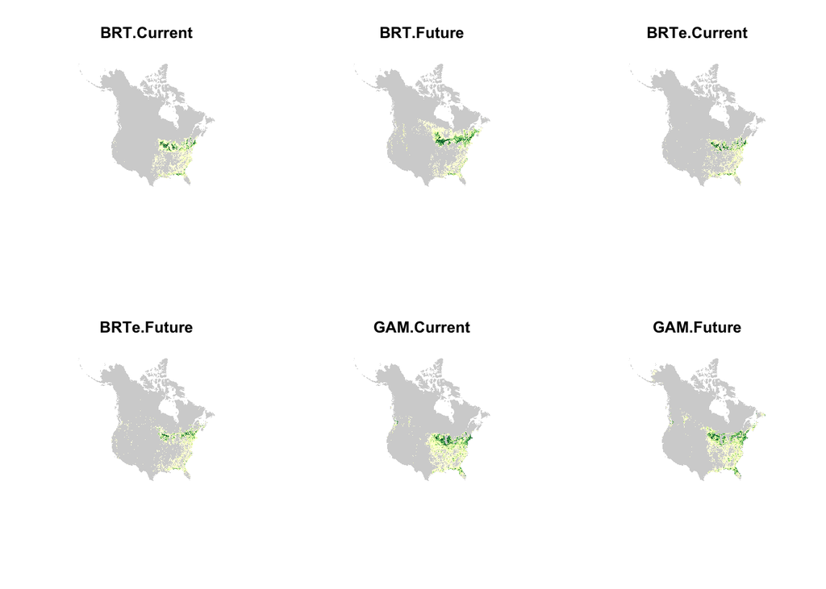

```r
#plot predictions
plot.SDM<-function(species){

  #read in data
  data<-readRDS(paste0("Lupine_SDMs/Models/Predictions/",species,".1k",".rds"))
  class(data)

  #make NAs 0
  data[is.na(data)]<-0

  #convert back into probabilities (0-1)
  data<-round(apply(data,2,function (x) x/100),2)

  #make vec from raster base
  basePixelNu <- dim(canusa)[1]*dim(canusa)[2]
  vec <- 1:basePixelNu

  #add data
  mat<-matrix(NA, nrow = length(vec), ncol = ncol(data))
  rownames(mat)<-vec
  mat[row.names(data),]<-data[]
  colnames(mat)<-colnames(data)

  #set breaks and colours
  require(RColorBrewer)
  breakpoints <- seq(0,1,length.out=100)
  colors <- colorRampPalette(brewer.pal(9,'YlGn'))(100)
  colors<-c("lightgrey",colors)
  arg <- list(at=breakpoints, labels=round(breakpoints, 1))

  #plot it!
  par(mfrow=c(2,3))
  for (i in 1:ncol(mat)){
  r <- canusa
  r[] <- mat[,i]
  r[is.na(canusa)] <- NA
  plot(r,breaks=c(breakpoints),col=c(colors),axes=F,box=F,main=colnames(mat)[i],axis.args=arg,legend=F)


  }

}


## run function for Lupinus perennis
plot.SDM("Lupinus perennis")
```

We can also plot the change between current and predicted future distrubtions of *Lupinus perennis* with the `plot.change` function.

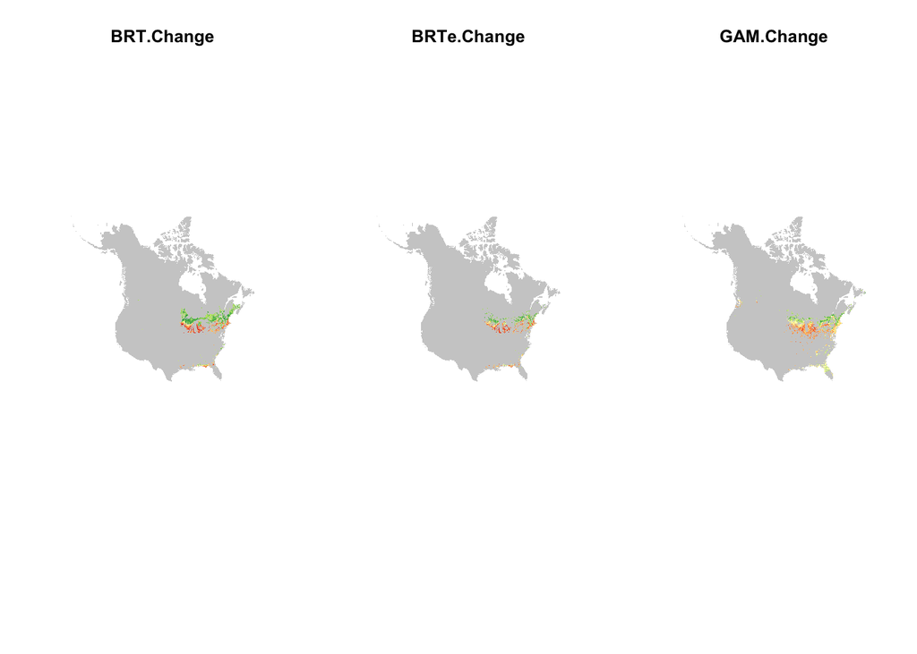

```r
plot.change<-function(species,threshold){

    #read in data
  data<-readRDS(paste0("Lupine_SDMs/Models/Predictions/",species,".1k",".rds"))

  #make NAs 0
  data[is.na(data)]<-0

  #threshold to make maps nicer
  data[(data<threshold)]<-0


  #convert back into probabilities (0-1)
  #data<-round(apply(data,2,function (x) x/100),2)

  colnames(data)

  #calc change metric
  #order = "BRT.Current","BRT.Future","BRTe.Current","BRTe.Future","GAM.Current","GAM.Future"
  change<-matrix(data=NA,ncol=3,nrow=nrow(data))
  change[,1]=data[,2]-data[,1]
  change[,2]=data[,4]-data[,3]
  change[,3]=data[,6]-data[,5]
  colnames(change)=c("BRT.Change","BRTe.Change","GAM.Change")
  rownames(change)=rownames(data)

  #calc mx and mn
  mx.1<-max(change[,1],na.rm=T)
  mx.2<-max(change[,2],na.rm=T)
  mx.3<-max(change[,3],na.rm=T)

  maxes<-c(mx.1,mx.2,mx.3)

  mn.1<-min(change[,1],na.rm=T)
  mn.2<-min(change[,2],na.rm=T)
  mn.3<-min(change[,3],na.rm=T)

  mins<-c(mn.1,mn.2,mn.3)


  #add back in NAs but make them 2
  change[which(data[,1]==0 & data[,2]==0),1]<-200
  change[which(data[,3]==0 & data[,4]==0),2]<-200
  change[which(data[,5]==0 & data[,6]==0),3]<-200

  #make vec from raster base
  basePixelNu <- dim(canusa)[1]*dim(canusa)[2]
  vec <- 1:basePixelNu

  #add data
  mat<-matrix(NA, nrow = length(vec), ncol = ncol(change))
  rownames(mat)<-vec
  mat[row.names(change),]<-change[]
  colnames(mat)<-colnames(change)

  #plot it!
  par(mfrow=c(1,3))
  for (i in 1:ncol(mat)){

    #set breaks and colours
    require(RColorBrewer)
    breakpoints <- seq(mins[i],maxes[i],length.out=100)
    breakpoints <-c(breakpoints,199,200)
    colors <- colorRampPalette(brewer.pal(9,'RdYlGn'))(100)
    colors<-c(colors,"#CDCDCD")
    arg <- list(at=breakpoints, labels=round(breakpoints, 1))

    r <- canusa
    r[] <- mat[,i]
    r[is.na(canusa)] <- NA
    plot(r,breaks=c(breakpoints),col=c(colors),axes=F,box=F,main=colnames(mat)[i],axis.args=arg,legend=F)

  }

}


plot.change("Lupinus perennis", 30)
```

### Model results

```r
par(mfrow=c(1,1))
s <- "Lupinus perennis"
BRT <- readRDS(file=paste0("Lupine_SDMs/Models/BRTs/",s,".BRT",".rds"))
BRTe <- readRDS(file=paste0("Lupine_SDMs/Models/BRTs/",s,".BRTe",".rds"))

#relative importance of different variables
summary(BRT) #this tells you how important each variable was
summary(BRTe) #this tells you how important each variable was

#individual variable plots
# sam - what are these actually telling us?
gbm.plot(BRT, n.plots=11, plot.layout=c(4, 3), write.title = F)
gbm.plot(BRTe, n.plots=11, plot.layout=c(4, 3), write.title = F)
```

[output not shown]

### Saving as a geotiff file

```r
write.raster<-function(species){
  species="Lupinus perennis"

  #read in data
  data<-readRDS(paste0("Lupine_SDMs/Models/Predictions/",species,".1k",".rds"))
  class(data)

  #make NAs 0
  data[is.na(data)]<-0

  #convert back into probabilities (0-1)
  data<-round(apply(data,2,function (x) x/100),2)

for (i in 1:ncol(data)){
  i=1
  r <- (canusa)
  r[] <- data[,i]
  r[is.na(canusa)] <- NA
  r[(r==0)]<-NA

  rast(r)

  writeRaster(rast(r),filename=paste0("Lupine_SDMs/Models/Predictions/",species,".",colnames(data)[i],".1k",".tiff"),overwrite=T)

}

}


write.raster("Lupinus perennis")
```